# DSE 511 Final Project Cluster Analysis in R

Cecilia Albert-Black

2025-11-11

Set working directory to R code folder

```r
setwd("C:/Users/q4q/repos/DSE511_Final_Project/Step 3. Cluster Analysis/R Code")
```

Load necessary libraries (must be installed first)

```r
library(readr)
library(tidyverse)
library(fitdistrplus)
library(factoextra) #for pca
library(klaR) # K-modes clustering
library(psych) # for KMO test
```

Import dataset from Step 1. Data Cleaning

```r
clean_df <- read_csv("C:/Users/q4q/repos/DSE511_Final_Project/Step 1. Data Cleaning/R code/outbreak_clean_r_v3.csv")
head(clean_df)
```

```
## # A tibble: 6 × 31
##    Year Month Date    Season State     Region Primary_mode Setting Setting_group
##   <dbl> <dbl> <chr>   <chr>  <chr>     <chr>  <chr>        <chr>   <chr>
## 1  1971     2 1971-02 Winter Californ… West   Water        Restau… Food Service
## 2  1971     6 1971-06 Summer Arkansas  South  Water        Store   Food Service
## 3  1971     6 1971-06 Summer Missouri  Midwe… Water        Subdiv… Community/Pu…
## 4  1971     6 1971-06 Summer Alabama   South  Water        Unknown Unknown
## 5  1971     6 1971-06 Summer Vermont   North… Water        Commun… Community/Pu…
## 6  1971     6 1971-06 Summer Oregon    West   Water        Restau… Food Service
## # ℹ 22 more variables: Etiology <chr>, Etiology_group <chr>,
## #   IFSAC_category <chr>, Food_vehicle <chr>, Water_exposure <chr>,
## #   Water_type <chr>, Water_type_group <chr>, Animal_type <chr>,
## #   Animal_type_group <chr>, Illnesses <dbl>, Hospitalizations <dbl>,
## #   Deaths <dbl>, Hospitalizations_std <dbl>, Deaths_std <dbl>,
## #   Illnesses_std <dbl>, Hosp_per_ill <dbl>, Death_per_ill <dbl>,
## #   Food_vehicle_missing <chr>, Water_exposure_missing <chr>, …
```

## Cluster Analysis

### I. Hierarchical

**Assumptions**

- Data must be numeric or convertible to a distance metric
- Variables must be on comparable scales (standardized variables)
- Data should have some natural separation, the structure cannot be completely random
- Variables can be non-parametric

**Limitations encountered:** hclust() function in base R could not handle more than 65,536 observations (the dataset has 66,713).

### II. K-Means

**Assumptions**: continuous variables with Euclidean distances.

**Limitations**: many of our variables (especially hospitalizations and deaths) fail these assumptions because they are discrete, right-skewed, and Poisson/logarithmically distributed. Thus, we will perform a k-means cluster analysis on year, month, and illnesses since they are closest to being normally distributed and continuous.

#### i. Selecting Variables

Let’s re-assess their distribution:

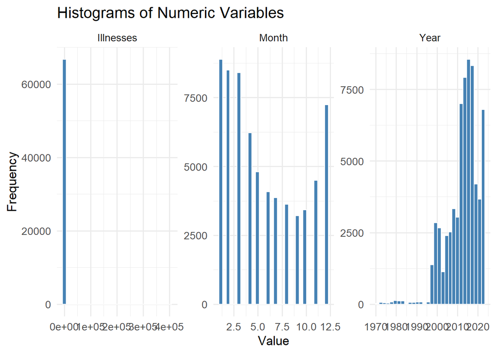

```r
# 1. Define numeric variables
num_vars <- c(
  "Year", "Month",
  "Illnesses")

# 2. Reshape the numeric data for plotting
num_vars_long <- clean_df %>%
  dplyr::select(all_of(num_vars)) %>%
  pivot_longer(everything(), names_to = "variable", values_to = "value")

# 3. Plot histograms for each numeric variable
ggplot(num_vars_long, aes(x = value)) +
  geom_histogram(bins = 30, fill = "steelblue", color = "white") +
  facet_wrap(~ variable, scales = "free") +
  theme_minimal(base_size = 13) +
  labs(
    title = "Histograms of Numeric Variables",
    x = "Value",
    y = "Frequency"
  )
```

Illnesses are heavily skewed, but probably due to the one outlier identified in the EDA (1993-03-01 had 403,114 illness cases).

Let’s omit that outlier for this cluster analysis.

```r
# Identify the observation within the dataset
library(dplyr)

row_number <- clean_df %>%
  filter(Year == 1993) %>%
  filter(Month == 3) %>%
  filter(State == "Wisconsin")

row_number
```

```
## # A tibble: 1 × 31
##    Year Month Date    Season State     Region Primary_mode Setting Setting_group
##   <dbl> <dbl> <chr>   <chr>  <chr>     <chr>  <chr>        <chr>   <chr>
## 1  1993     3 1993-03 Spring Wisconsin Midwe… Water        Commun… Community/Pu…
## # ℹ 22 more variables: Etiology <chr>, Etiology_group <chr>,
## #   IFSAC_category <chr>, Food_vehicle <chr>, Water_exposure <chr>,
## #   Water_type <chr>, Water_type_group <chr>, Animal_type <chr>,
## #   Animal_type_group <chr>, Illnesses <dbl>, Hospitalizations <dbl>,
## #   Deaths <dbl>, Hospitalizations_std <dbl>, Deaths_std <dbl>,
## #   Illnesses_std <dbl>, Hosp_per_ill <dbl>, Death_per_ill <dbl>,
## #   Food_vehicle_missing <chr>, Water_exposure_missing <chr>, …
```

```r
clean_df_2 <- clean_df %>%
  filter(Year != 1993) %>%
  filter(Month != 3) %>%
  filter(State != "Wisconsin")

# Check
row_number <- clean_df_2 %>%
  filter(Year == 1993) %>%
  filter(Month == 3) %>%
  filter(State == "Wisconsin")

# Should be blank because this observation does not exist in clean_df_2
row_number
```

```
## # A tibble: 0 × 31
## # ℹ 31 variables: Year <dbl>, Month <dbl>, Date <chr>, Season <chr>,
## #   State <chr>, Region <chr>, Primary_mode <chr>, Setting <chr>,
## #   Setting_group <chr>, Etiology <chr>, Etiology_group <chr>,
## #   IFSAC_category <chr>, Food_vehicle <chr>, Water_exposure <chr>,
## #   Water_type <chr>, Water_type_group <chr>, Animal_type <chr>,
## #   Animal_type_group <chr>, Illnesses <dbl>, Hospitalizations <dbl>,
## #   Deaths <dbl>, Hospitalizations_std <dbl>, Deaths_std <dbl>, …
```

Check histogram of Illnesses now

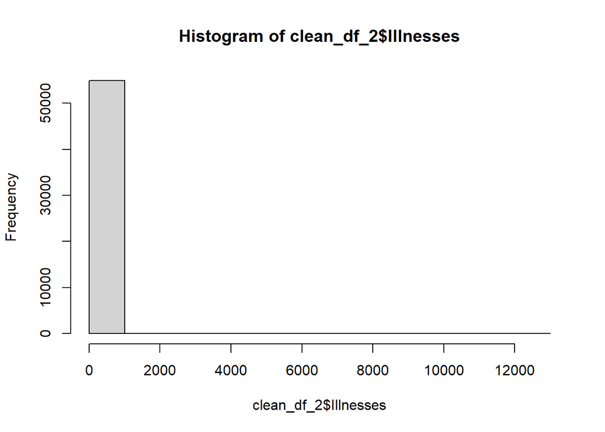

```r
hist(clean_df_2$Illnesses)
```

Still not normal, so let’s log-transform it: log illnesses

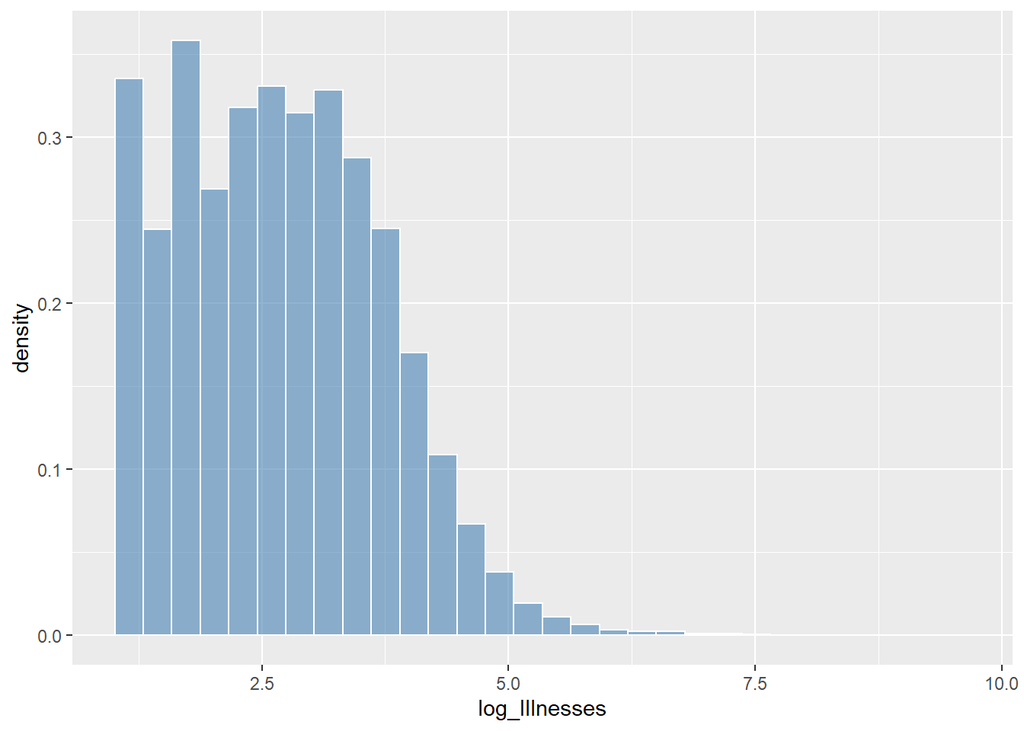

```r
# Create a new variable: log (Illnesses+1)
clean_df_2$log_Illnesses <- log(clean_df_2$Illnesses +1)

# Histogram
ggplot(clean_df_2, aes(x = log_Illnesses)) +
  geom_histogram(aes(y = after_stat(density)),
                 bins = 30, fill = "steelblue", color = "white", alpha = 0.6)
```

#### ii. Selecting Number of Clusters

```r
num_vars <- clean_df_2 %>%
  dplyr::select(
    log_Illnesses,
    Year,
    Month
  )
```

Scale the variables

```r
std_num_vars<- num_vars %>%
      mutate(across(where(is.numeric), ~(scale(.) %>% as.vector)))

# check
str(std_num_vars)
```

```
## tibble [54,929 × 3] (S3: tbl_df/tbl/data.frame)
##  $ log_Illnesses: num [1:54929] -1.49 1.84 -1.49 -1.21 -1.21 ...
##  $ Year         : num [1:54929] -5.37 -5.37 -5.37 -5.37 -5.37 ...
##  $ Month        : num [1:54929] -1.0694 -0.0222 -0.0222 -0.0222 -0.0222 ...
```

Check for missing values (should be none)

```r
summary(is.na(std_num_vars))
```

```
##  log_Illnesses      Year           Month
##  Mode :logical   Mode :logical   Mode :logical
##  FALSE:54929     FALSE:54929     FALSE:54929
```

Scree plot

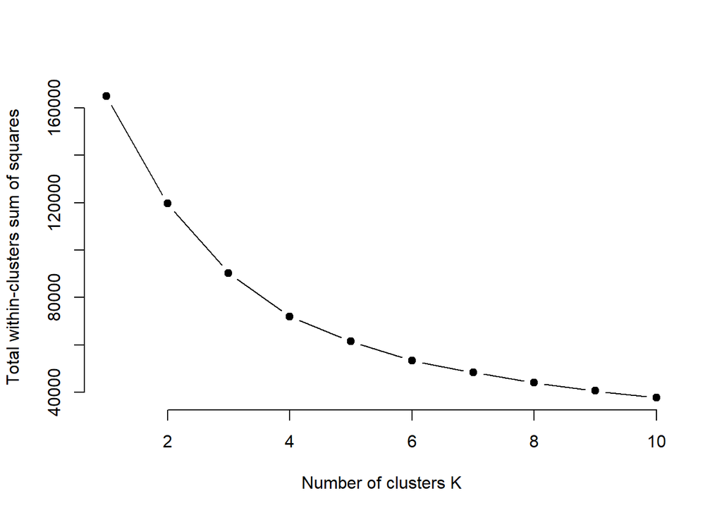

```r
library(factoextra)

set.seed(123)

# function to compute total within-cluster sum of square
wss <- function(k) {
  kmeans(std_num_vars, k, nstart = 10 )$tot.withinss
}

# Compute and plot wss for k = 1 to k = 10
k.values <- 1:10

# extract wss for 2-10 clusters
wss_values <- map_dbl(k.values, wss)
plot(k.values, wss_values,
       type="b", pch = 19, frame = FALSE,
       xlab="Number of clusters K",
       ylab="Total within-clusters sum of squares")
```

Looks like 4 clusters is suitable.

#### iii. Clustering

```r
# PCA
pca_result <- prcomp(std_num_vars, scale. = TRUE)

# Extract scores
pca_scores <- as.data.frame(pca_result$x[, 1:3])

# Se seed for reproducibility
set.seed(123)

# RUn k-means
kmeans_result <- kmeans(pca_scores, centers = 4, nstart = 25)
clean_df_2$cluster <- factor(kmeans_result$cluster)
```

Visualize

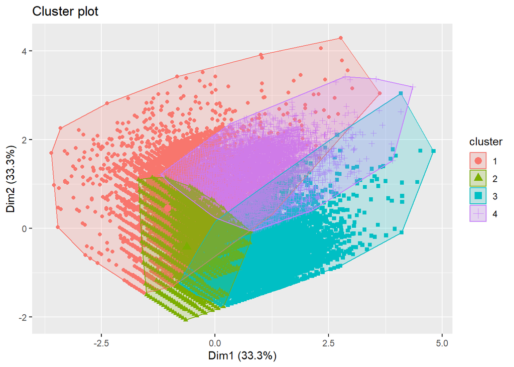

```r
# Plot
pca_clust <-
  fviz_cluster(kmeans_result, data = pca_scores, geom = "point", ellipse = TRUE)

# View
pca_clust
```

Looks really weird…

#### `iv. Characterizing the Clusters

Determine the size of each cluster

```r
table(kmeans_result$cluster)
```

```
##
##     1     2     3     4
## 10837 14872 17398 11822
```

Add clusters back to dataset

```r
# Add cluster labels to the kmodes_input data
kmodes_clusters_2 <- factor(kmeans_result$cluster)

clean_df_2 <- clean_df_2 %>%
  mutate(cluster = kmodes_clusters_2)

# Quick look at cluster sizes
clean_df_2 %>%
  count(cluster)
```

```
## # A tibble: 4 × 2
##   cluster     n
##   <fct>   <int>
## 1 1       10837
## 2 2       14872
## 3 3       17398
## 4 4       11822
```

Visualize by categorical variable

```r
library(ggplot2)
library(dplyr)

# Helper function
plot_cluster_comp <- function(data, var_name) {
  ggplot(
    data,
    aes(x = .data[[var_name]], fill = cluster)
  ) +
    geom_bar(position = "fill") +           # proportion within each category
    coord_flip() +
    theme_minimal(base_size = 12) +
    labs(
      title = paste("Cluster Composition by", var_name),
      x = var_name,
      y = "Proportion"
    ) +
    theme(
      legend.position = "bottom",
      axis.text.y = element_text(size = 8)
    )
}

# By Year
p_year <- plot_cluster_comp(clean_df_2, "Year")

# By Month
p_month <- plot_cluster_comp(clean_df_2, "Month")
```

Save plots

```r
ggsave("k_means_cluster_year.png", p_year, width = 7, height = 5, dpi = 300)
ggsave("k_means_cluster_month.png", p_month, width = 7, height = 5, dpi = 300)
```

View

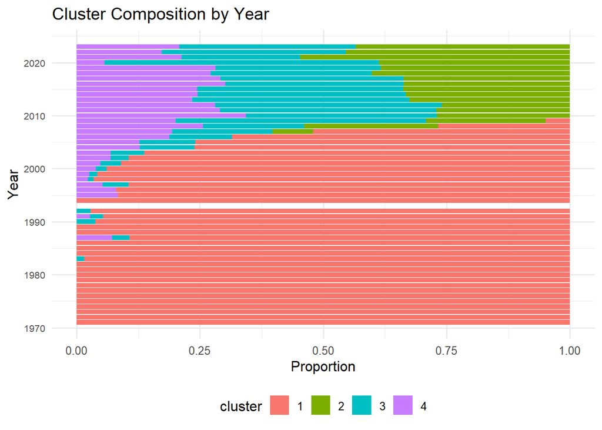

```r
p_year
```

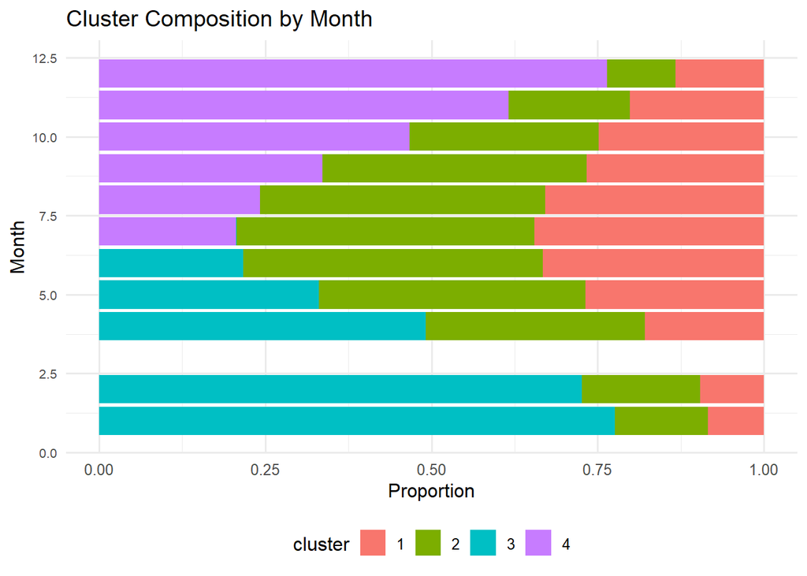

```r
p_month
```

Illness counts by cluster

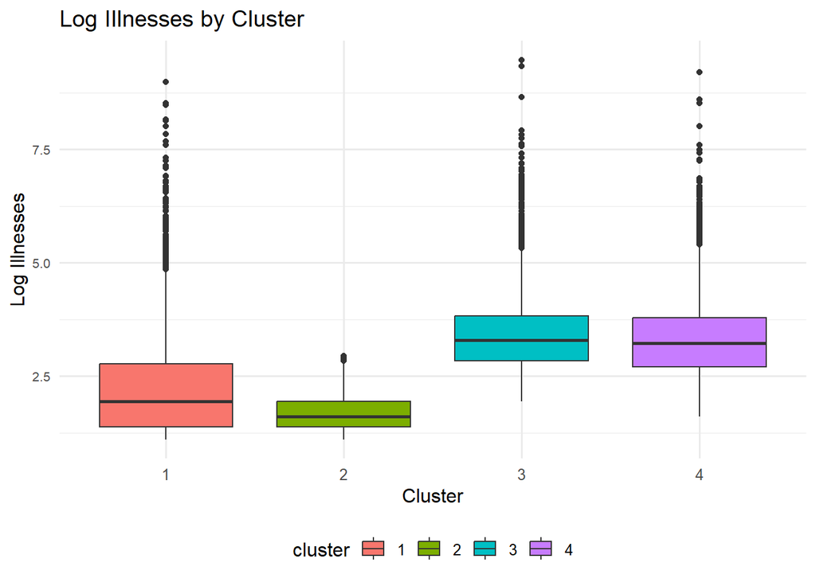

```r
p_ill <- ggplot(
    data = clean_df_2,
    aes(x = cluster, y = log_Illnesses, fill = cluster)
) +
    geom_boxplot() +
    theme_minimal(base_size = 12) +
    labs(
        title = "Log Illnesses by Cluster",
        x = "Cluster",
        y = "Log Illnesses"
    ) +
    theme(
        legend.position = "bottom",
        axis.text.y = element_text(size = 8)
    )

p_ill
```

Description of clusters

- **Cluster 1**: Outbreaks primarily during years 1970-2007, peaking in warm months
- **Cluster 2**: Outbreaks since 2007, peaking in warm months
- **Cluster 3**: Outbreaks primarily since 2007, peaking in late winter
- **Cluster 4**: Outbreaks primarily since 1995, peaking in early winter

### III. K-Modes

**Assumptions**

- Variables must be categorical
- Variables must not have any missing data
- Categories must have a mode (most frequent category) as their center
- Categories must have a similar size/density

**Limitations**: None!

**Notes**: some categorical variables only apply to some of the observations; thus, we will replace NAs with “Not Applicable”.

#### i. Selecting Variables

Select categorical variables that applt to all outbreaks by creating a vector of character names

```r
cat_vars <- c(
  "Date",
  "Season",
  "Region",
  "Primary_mode",
  "Setting_group",
  "Etiology_group"
)
```

Create a categorical dataset and convert to factors

```r
kmodes_df <- clean_df %>%
  dplyr::select(all_of(cat_vars)) %>%
  mutate(
    across(everything(), as.factor)
  )

# sanity check
dim(kmodes_df)
```

```
## [1] 66713     6
```

```r
names(kmodes_df)
```

```
## [1] "Date"           "Season"         "Region"         "Primary_mode"
## [5] "Setting_group"  "Etiology_group"
```

Ensure there are no missing values in these categories (there should be no TRUE counts)

```r
summary(is.na(kmodes_df))
```

```
##     Date           Season          Region        Primary_mode
##  Mode :logical   Mode :logical   Mode :logical   Mode :logical
##  FALSE:66713     FALSE:66713     FALSE:66713     FALSE:66713
##  Setting_group   Etiology_group
##  Mode :logical   Mode :logical
##  FALSE:66713     FALSE:66713
```

Convert to dataframe

```r
kmodes_input <- as.data.frame(kmodes_df)
```

#### ii. Selecting Number of Clusters (Elbow method)

Run k-modes on different sizes (e.g. from 1-10)

```r
set.seed(123)

kmodes_results <- vector("list", length = 10)

for (k in 1:5) {
  cat("Fitting k =", k, "\n")

  kmodes_results[[k]] <- klaR::kmodes(
    kmodes_input,
    modes   = k,
    iter.max = 50
  )
}
```

```
## Fitting k = 1
## Fitting k = 2
## Fitting k = 3
## Fitting k = 4
## Fitting k = 5
```

```r
names(kmodes_results) <- paste0("k_", 1:10)
```

For each size, plot the cost function (i.e. within-cluster dissimilarities) against the number of clusters (k) to identify the elbow point

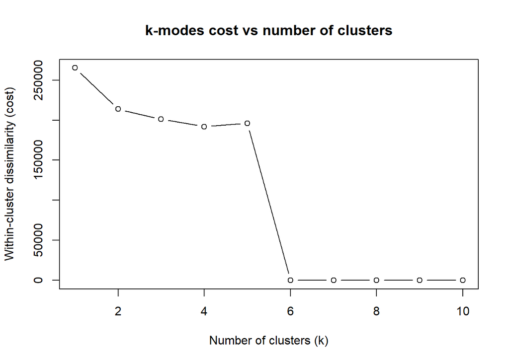

```r
# Extract within-cluster dissimilarities (cost) by cluster size
kmodes_costs <- sapply(
  kmodes_results,
  function(x) sum(as.numeric(x$withindiff))
)

plot(
  1:10, kmodes_costs, type = "b",
  xlab = "Number of clusters (k)",
  ylab = "Within-cluster dissimilarity (cost)",
  main = "k-modes cost vs number of clusters"
)
```

Identify the elbow point in the plot, where the rate of decrease in the cost function significanlty slows down; this point suggests the optimal number of clusters.

It seems like 2-5 clusters could be sufficient.

Since it’s hard to determine what cluster size to use, we’ll use both

#### iii. Characterizing Clusters

##### a. 2 Clusters

```r
# 2 clusters
kmodes_result_2 <-
  klaR::kmodes(
  kmodes_input,
  modes = 2,
  iter.max = 50
  )

# Most common categories by cluster
kmodes_result_2$modes
```

```
##      Date Season  Region     Primary_mode Setting_group Etiology_group
## 1 2015-03 Spring Midwest             Food  Food Service        Unknown
## 2 2017-01 Winter Midwest Person-to-person    Healthcare      Norovirus
```

Add clusters back to dataset

```r
# Add cluster labels to the kmodes_input data
kmodes_clusters_2 <- factor(kmodes_result_2$cluster)

kmodes_df_2 <- kmodes_input %>%
  mutate(cluster = kmodes_clusters_2)

# Quick look at cluster sizes
kmodes_df_2 %>%
  count(cluster)
```

```
##   cluster     n
## 1       1 29649
## 2       2 37064
```

Visualize

```r
library(ggplot2)
library(dplyr)

# Helper function
plot_cluster_comp <- function(data, var_name) {
  ggplot(
    data,
    aes(x = .data[[var_name]], fill = cluster)
  ) +
    geom_bar(position = "fill") +           # proportion within each category
    coord_flip() +
    theme_minimal(base_size = 12) +
    labs(
      title = paste("Cluster Composition by", var_name),
      x = var_name,
      y = "Proportion"
    ) +
    theme(
      legend.position = "bottom",
      axis.text.y = element_text(size = 8)
    )
}

# Create plots -----------------------------------------------------------

p_region <- plot_cluster_comp(kmodes_df_2, "Region")
p_season <- plot_cluster_comp(kmodes_df_2, "Season")
p_primary <- plot_cluster_comp(kmodes_df_2, "Primary_mode")
p_etiology <- plot_cluster_comp(kmodes_df_2, "Etiology_group")

# Save plots -------------------------------------------------------------

ggsave("k_modes_cluster_region.png", p_region, width = 7, height = 5, dpi = 300)
ggsave("k_modes_cluster_season.png", p_season, width = 7, height = 5, dpi = 300)
ggsave("k_modes_cluster_primary_mode.png", p_primary, width = 7, height = 5, dpi = 300)
ggsave("k_modes_cluster_etiology_group.png", p_etiology, width = 7, height = 5, dpi = 300)
```

View plots

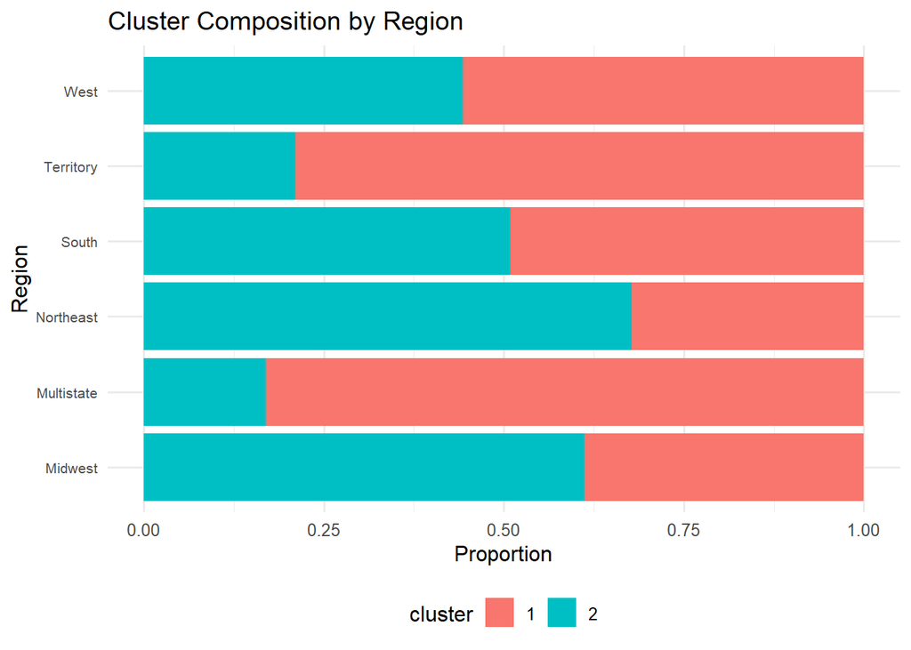

```r
p_region
```

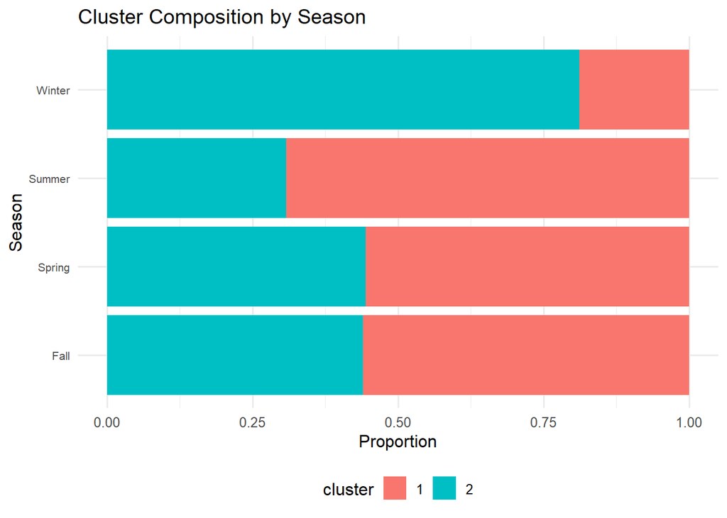

```r
p_season
```

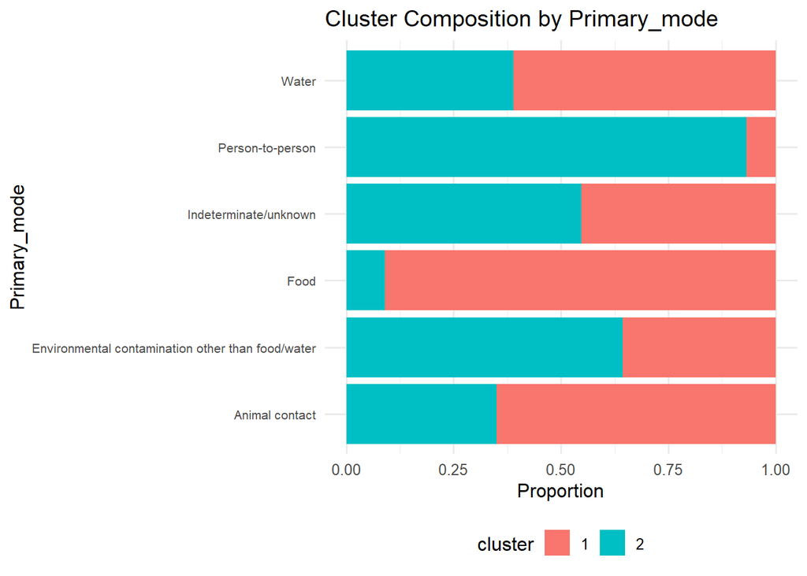

```r
p_primary
```

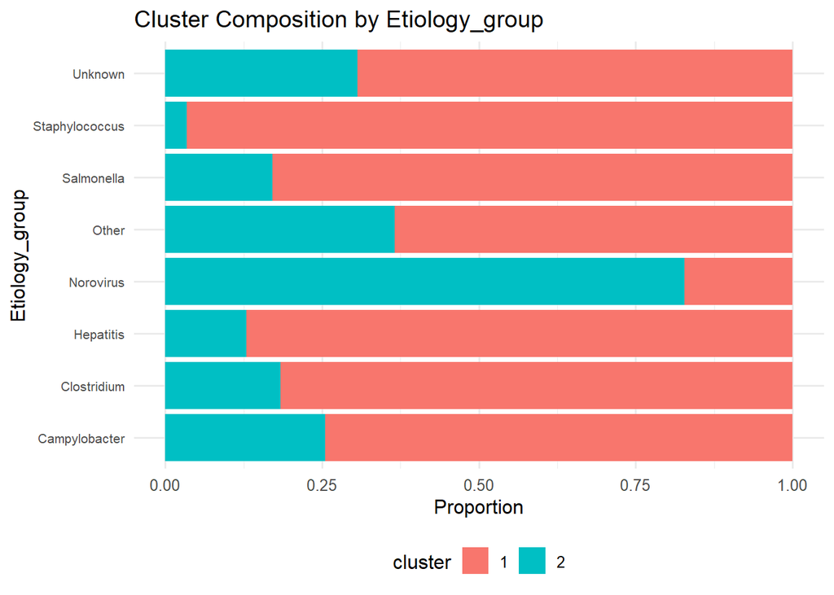

```r
p_etiology
```

Cluster characteristics

- **Cluster 1**: Outbreaks across multistates and territories in warmer seasons primarily caused by food borne illnesses by Staph, Hepatitis, and Salmonella pathogens.
- **Cluster 2**: Outbreaks across the Midwest and Northeast in winter primarily caused by person-to-person contact primarily by Norovirus pathogens.

##### b. 3 Clusters

```r
# 3 clusters
kmodes_result_3 <-
  klaR::kmodes(
  kmodes_input,
  modes = 3,
  iter.max = 50
  )

# Most common category for each cluster
kmodes_result_3$modes
```

```
##      Date Season  Region     Primary_mode Setting_group Etiology_group
## 1 2012-02 Winter   South Person-to-person    Healthcare        Unknown
## 2 2023-03 Spring Midwest Person-to-person    Healthcare      Norovirus
## 3 2018-11   Fall    West             Food  Food Service      Norovirus
```

Add clusters back to dataset

```r
# Add cluster labels to the kmodes_input data
kmodes_clusters_3 <- factor(kmodes_result_3$cluster)

kmodes_df_3 <- kmodes_input %>%
  mutate(cluster = kmodes_clusters_3)

# Quick look at cluster sizes
kmodes_df_3 %>%
  count(cluster)
```

```
##   cluster     n
## 1       1 18860
## 2       2 24783
## 3       3 23070
```

Visualize

```r
library(ggplot2)
library(dplyr)

# Helper function
plot_cluster_comp <- function(data, var_name) {
  ggplot(
    data,
    aes(x = .data[[var_name]], fill = cluster)
  ) +
    geom_bar(position = "fill") +           # proportion within each category
    coord_flip() +
    theme_minimal(base_size = 12) +
    labs(
      title = paste("Cluster Composition by", var_name),
      x = var_name,
      y = "Proportion"
    ) +
    theme(
      legend.position = "bottom",
      axis.text.y = element_text(size = 8)
    )
}

# Create plots -----------------------------------------------------------

p_region <- plot_cluster_comp(kmodes_df_3, "Region")
p_season <- plot_cluster_comp(kmodes_df_3, "Season")
p_primary <- plot_cluster_comp(kmodes_df_3, "Primary_mode")
p_etiology <- plot_cluster_comp(kmodes_df_3, "Etiology_group")

# Save plots -------------------------------------------------------------

ggsave("k_modes_cluster_region.png", p_region, width = 7, height = 5, dpi = 300)
ggsave("k_modes_cluster_season.png", p_season, width = 7, height = 5, dpi = 300)
ggsave("k_modes_cluster_primary_mode.png", p_primary, width = 7, height = 5, dpi = 300)
ggsave("k_modes_cluster_etiology_group.png", p_etiology, width = 7, height = 5, dpi = 300)
```

View plots

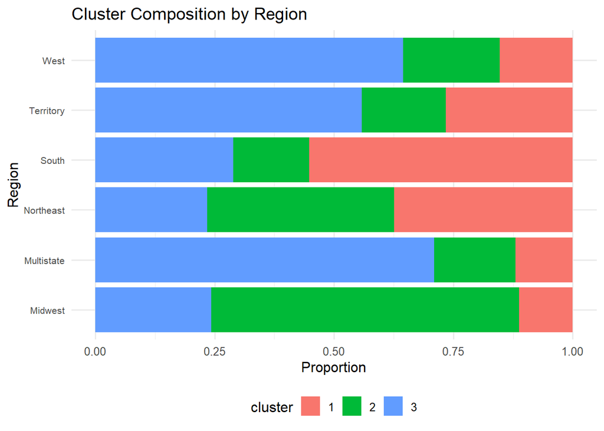

```r
p_region
```

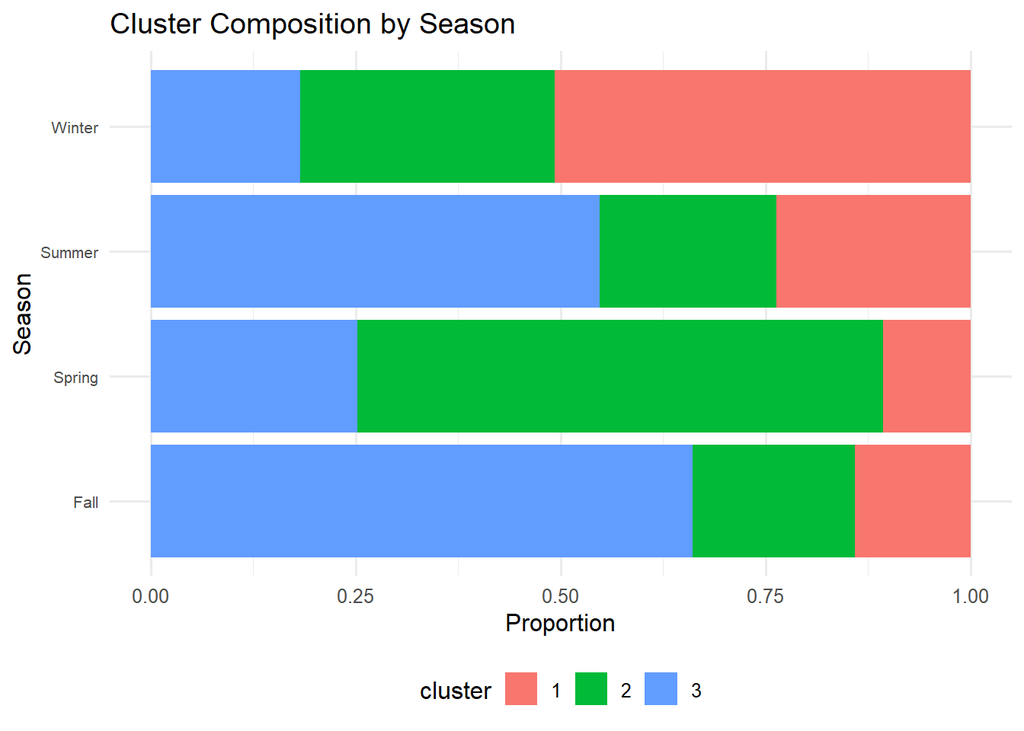

```r
p_season
```

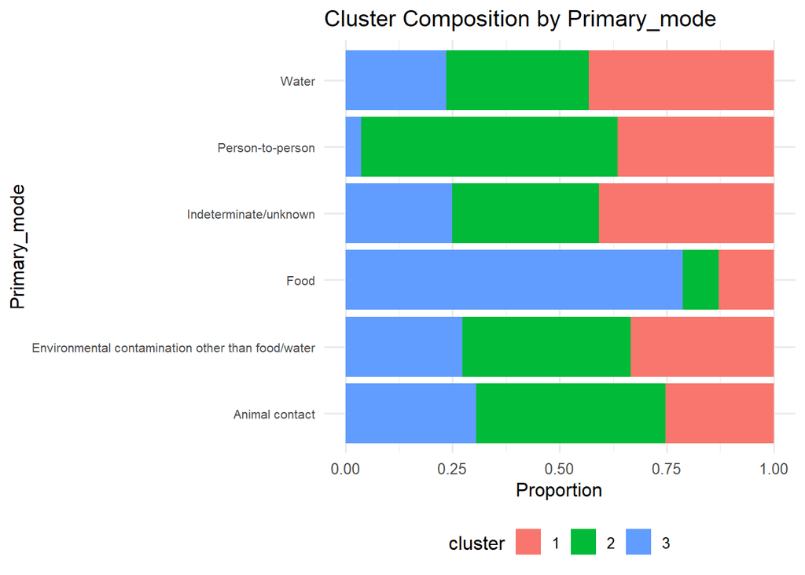

```r
p_primary
```

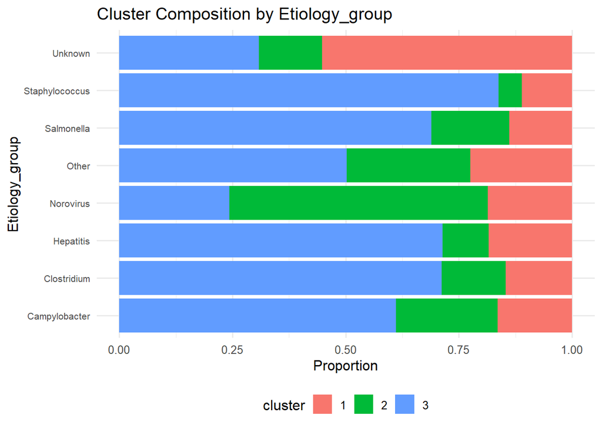

```r
p_etiology
```

Cluster characteristics

- **Cluster 1**: Outbreaks primarily in the Southern US peaking in winter, transmitted in a variety of ways from unknown etiologies.
- **Cluster 2**: Outbreaks primarily in the Midwest and Northeast peaking in Spring, transmitted in a variety of ways primarily from the Norovirus etiology.
- **Cluster 3**: Outbreaks across multistates, Western states and US territories peaking in Summer/Fall, mainly transmitted via food primarily from Staph and Salmonella etiologies.

##### c. 4 Clusters

```r
# 4 clusters
kmodes_result_4 <-
  klaR::kmodes(
  kmodes_input,
  modes = 4,
  iter.max = 50
  )

# Most common category for each cluster
kmodes_result_4$modes
```

```
##      Date Season  Region     Primary_mode Setting_group Etiology_group
## 1 2013-03 Spring   South Person-to-person    Healthcare      Norovirus
## 2 2017-01 Winter Midwest Person-to-person    Healthcare      Norovirus
## 3 2012-02 Winter   South             Food  Food Service        Unknown
## 4 2012-11   Fall    West             Food  Food Service      Norovirus
```

Add clusters back to dataset

```r
# Add cluster labels to the kmodes_input data
kmodes_clusters_4 <- factor(kmodes_result_4$cluster)

kmodes_df_4 <- kmodes_input %>%
  mutate(cluster = kmodes_clusters_4)

# Quick look at cluster sizes
kmodes_df_4 %>%
  count(cluster)
```

```
##   cluster     n
## 1       1 15140
## 2       2 21846
## 3       3 15429
## 4       4 14298
```

Visualize

```r
library(ggplot2)
library(dplyr)

# Helper function
plot_cluster_comp <- function(data, var_name) {
  ggplot(
    data,
    aes(x = .data[[var_name]], fill = cluster)
  ) +
    geom_bar(position = "fill") +           # proportion within each category
    coord_flip() +
    theme_minimal(base_size = 12) +
    labs(
      title = paste("Cluster Composition by", var_name),
      x = var_name,
      y = "Proportion"
    ) +
    theme(
      legend.position = "bottom",
      axis.text.y = element_text(size = 8)
    )
}

# Create plots -----------------------------------------------------------

p_region <- plot_cluster_comp(kmodes_df_4, "Region")
p_season <- plot_cluster_comp(kmodes_df_4, "Season")
p_primary <- plot_cluster_comp(kmodes_df_4, "Primary_mode")
p_etiology <- plot_cluster_comp(kmodes_df_4, "Etiology_group")

# Save plots -------------------------------------------------------------

ggsave("k_modes_cluster_region.png", p_region, width = 7, height = 5, dpi = 300)
ggsave("k_modes_cluster_season.png", p_season, width = 7, height = 5, dpi = 300)
ggsave("k_modes_cluster_primary_mode.png", p_primary, width = 7, height = 5, dpi = 300)
ggsave("k_modes_cluster_etiology_group.png", p_etiology, width = 7, height = 5, dpi = 300)
```

View

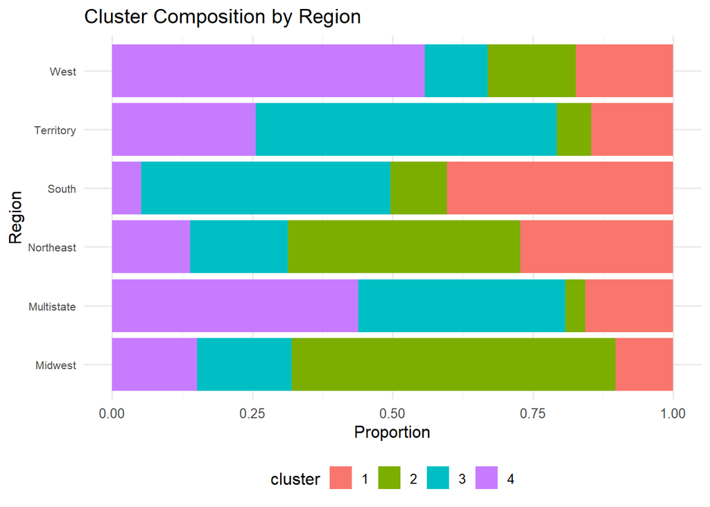

```r
p_region
```

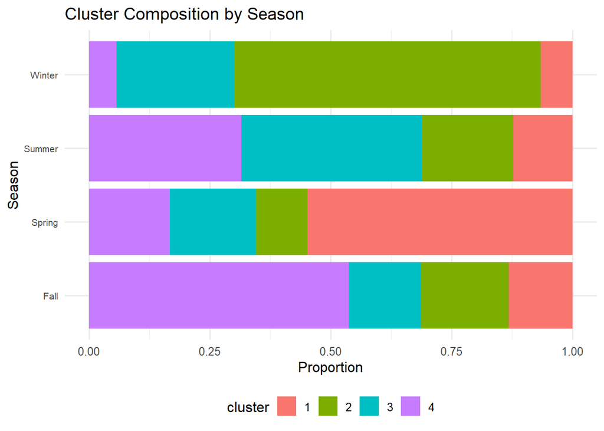

```r
p_season
```

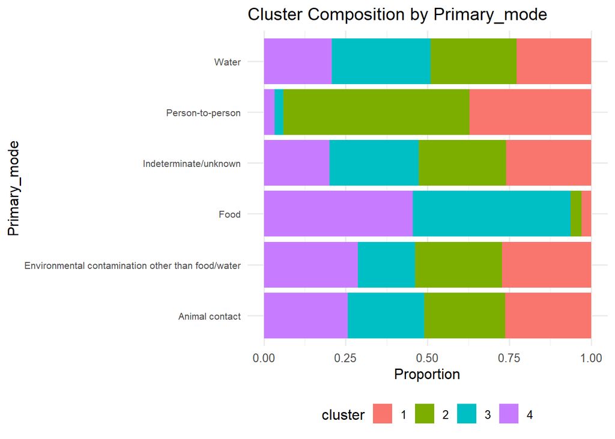

```r
p_primary
```

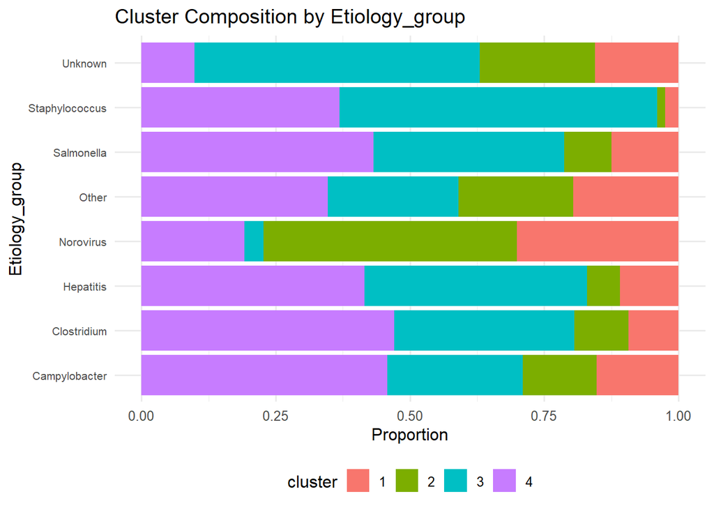

```r
p_etiology
```

Cluster characteristics

- **Cluster 1**: Outbreaks primarily in the Southern US states peaking in the springtime transmitted by a variety of ways (except food) caused primarily by Norovirus pathogens.
- **Cluster 2**: Outbreaks primarily in the Midwest and Northeast US states peaking in the winter transmitted primarily via person-to-person caused primarily by Norovirus pathogens.
- **Cluster 3**: Outbreaks primarily in US territories and Southern states peaking in summer transmitted primarily via food caused by a variety of pathogens.
- **Cluster 4:** Outbreaks primarily in Western US states and across multi-states peaking in fall transmitted primarily via food caused by a variety of pathogens.